# Biostat 212a Homework 2

Due Feb 6, 2024 @ 11:59PM

Author

Brilla Meng UID: 806329681

Published

February 6, 2024

## 1 ISL Exercise 4.8.1 (10pts)

**answer**: Since equation 4.2 is
$$p(X) = \frac{e^{\beta_0 + \beta_1 X}}{1 + e^{\beta_0 + \beta_1 X}}$$
I substrat one minus both parts, then I get
$$1 - p(X) = 1 - \frac{e^{\beta_0 + \beta_1 X}}{1 + e^{\beta_0 + \beta_1 X}} = \frac{1}{1 + e^{\beta_0 + \beta_1 X}},$$
and
$$\frac{1}{1 - p(X)} = 1 + e^{\beta_0 + \beta_1 X}$$
Therefore:
$$\frac{p(X)}{1 - p(X)} = \frac{e^{\beta_0 + \beta_1 X}}{1 + e^{\beta_0 + \beta_1 X}}(1 + e^{\beta_0 + \beta_1 X}),$$
And equation 4.3 is
$$\frac{p(X)}{1 - p(X)} = e^{\beta_0 + \beta_1 X}$$

## 2 ISL Exercise 4.8.6 (10pts)

1. **answer**: Just put the number into the equation, we get
   $$\begin{align*}
   P(Y = 1|X_1, X_2) = \frac{1}{1 + e^{-(\beta_0+\beta_1X_1+\beta_2X_2)}}
   \\\hat{\beta}_0 = -6, \quad \hat{\beta}_1 = 0.05, \quad \hat{\beta}_2 = 1
   \\P(Y = 1|X_1 = 40, X_2 = 3.5)
   = \frac{1}{1 + e^{-(\hat{\beta}_0+\hat{\beta}_1 \cdot 40+\hat{\beta}_2 \cdot 3.5)}}
   \\= \frac{1}{1 + e^{-(6+0.05 \cdot 40+1 \cdot 3.5)}}
   \\= \frac{1}{1 + e^{-(6+2+3.5)}}
   \\= \frac{1}{1 + e^{-(-0.5)}}
   \\= \frac{1}{1 + e^{0.5}}
   \\= \frac{1}{1 + 1.6487}
   \\= \frac{1}{2.6487}
   \\= 0.3775
   \end{align*}$$
   The probability that a student who studies for 40h and has an undergrad GPA of 3.5 gets an A in the class is 0.3775.
2. **answer**:
   $$\begin{align*}
   \text{logit}(P(Y = 1|X_1, X_2)) = \hat{\beta}_0 + \hat{\beta}_1X_1 + \hat{\beta}_2X_2 \\
   \text{logit}(0.5) = -6 + 0.05 \cdot X_1 + 1 \cdot 3.5 \\
   \log\left(\frac{0.5}{1 - 0.5}\right) = -6 + 0.05 \cdot X_1 + 3.5 \\
   \log(1) = -6 + 0.05 \cdot X_1 + 3.5 \\
   0 = -6 + 0.05X_1 + 3.5 \\
   X_1 = \frac{2.5}{0.05} \\
   X_1 = 50
   \end{align*}$$
   To have a 50% chance of getting an A in the class,he need to study at least 50h.

## 3 ISL Exercise 4.8.9 (10pts)

1. **answer**:

$$\frac{p(x)}{1 -p(x)}=0.37$$
we can transfer to
$$p(X) = \frac{0.37}{1 + 0.37} = 0.27$$
we have on average a fraction of 27% of people defaulting on their credit card payment.

2. **answer**: we add 16% to this equation we can get,
   $$\frac{p(x)}{1 -p(x)}= \frac{0.16}{1 + 0.16} = 0.19$$
   She has on average a fraction of 19% of people defaulting on their credit card payment.

## 4 ISL Exercise 4.8.13 (a)-(i) (50pts)

```r
library(ISLR)
library(corrplot)
summary(Weekly)
```

```
      Year           Lag1               Lag2               Lag3
 Min.   :1990   Min.   :-18.1950   Min.   :-18.1950   Min.   :-18.1950
 1st Qu.:1995   1st Qu.: -1.1540   1st Qu.: -1.1540   1st Qu.: -1.1580
 Median :2000   Median :  0.2410   Median :  0.2410   Median :  0.2410
 Mean   :2000   Mean   :  0.1506   Mean   :  0.1511   Mean   :  0.1472
 3rd Qu.:2005   3rd Qu.:  1.4050   3rd Qu.:  1.4090   3rd Qu.:  1.4090
 Max.   :2010   Max.   : 12.0260   Max.   : 12.0260   Max.   : 12.0260
      Lag4               Lag5              Volume            Today
 Min.   :-18.1950   Min.   :-18.1950   Min.   :0.08747   Min.   :-18.1950
 1st Qu.: -1.1580   1st Qu.: -1.1660   1st Qu.:0.33202   1st Qu.: -1.1540
 Median :  0.2380   Median :  0.2340   Median :1.00268   Median :  0.2410
 Mean   :  0.1458   Mean   :  0.1399   Mean   :1.57462   Mean   :  0.1499
 3rd Qu.:  1.4090   3rd Qu.:  1.4050   3rd Qu.:2.05373   3rd Qu.:  1.4050
 Max.   : 12.0260   Max.   : 12.0260   Max.   :9.32821   Max.   : 12.0260
 Direction
 Down:484
 Up  :605
```

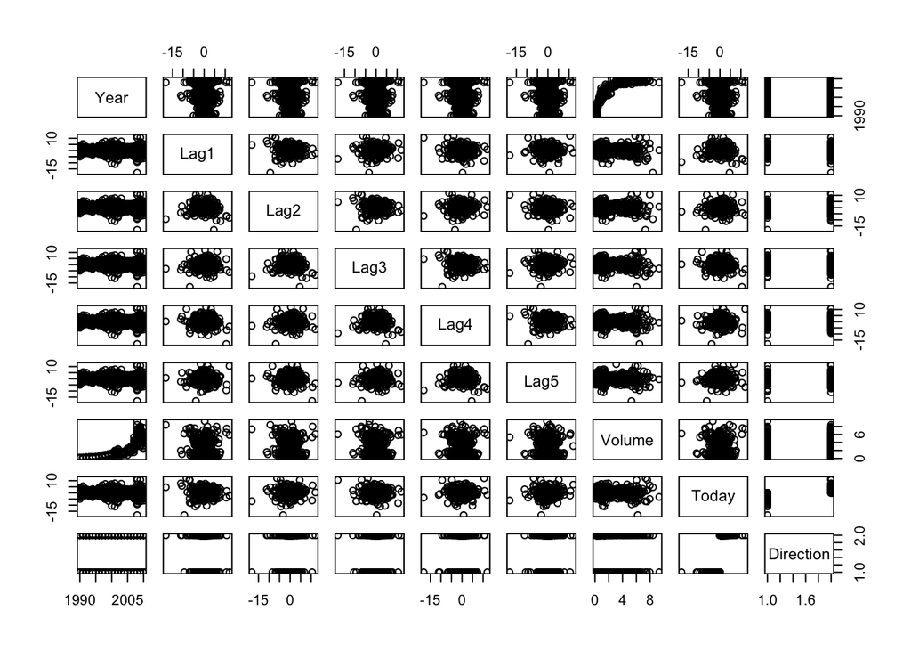

```r
pairs(Weekly)
```

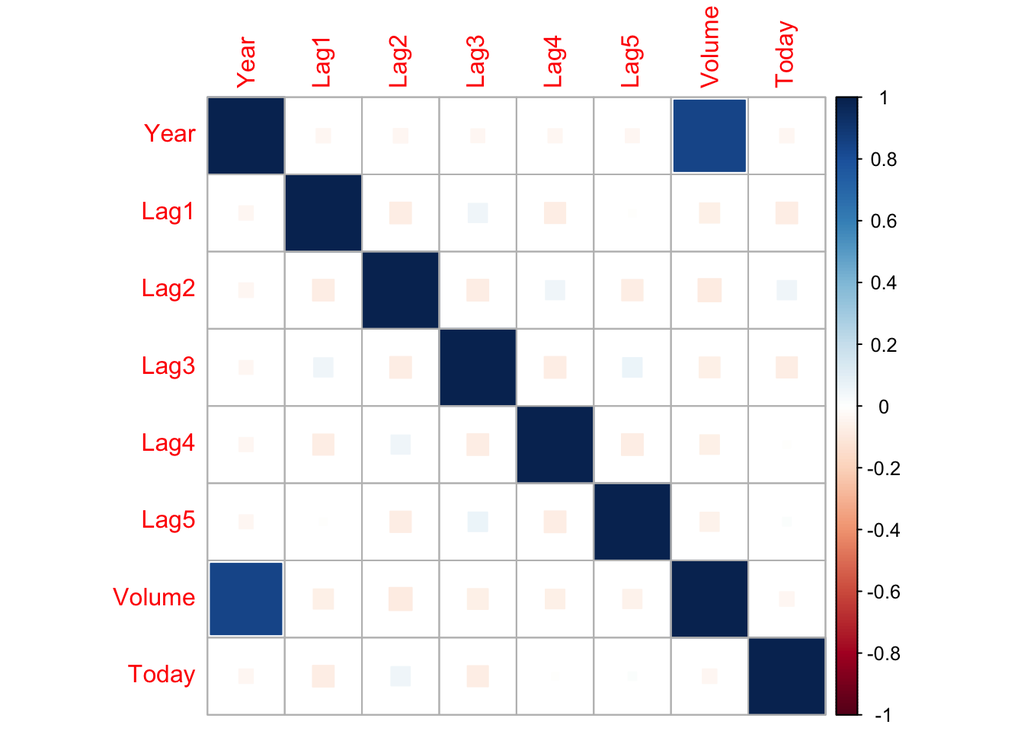

```r
corrplot(cor(Weekly[,-9]), method="square")
```

**answer**: The only variable that appears to be correlated with `Year` is `Volume`. The correlational plot doesn’t illustrate that any other variables are linearly related.

```r
attach(Weekly)
Weekly.fit<-glm(Direction~Lag1+Lag2+Lag3+Lag4+Lag5+Volume, data=Weekly,family=binomial)
summary(Weekly.fit)
```

```
Call:
glm(formula = Direction ~ Lag1 + Lag2 + Lag3 + Lag4 + Lag5 +
    Volume, family = binomial, data = Weekly)

Coefficients:
            Estimate Std. Error z value Pr(>|z|)
(Intercept)  0.26686    0.08593   3.106   0.0019 **
Lag1        -0.04127    0.02641  -1.563   0.1181
Lag2         0.05844    0.02686   2.175   0.0296 *
Lag3        -0.01606    0.02666  -0.602   0.5469
Lag4        -0.02779    0.02646  -1.050   0.2937
Lag5        -0.01447    0.02638  -0.549   0.5833
Volume      -0.02274    0.03690  -0.616   0.5377
---
Signif. codes:  0 '***' 0.001 '**' 0.01 '*' 0.05 '.' 0.1 ' ' 1

(Dispersion parameter for binomial family taken to be 1)

    Null deviance: 1496.2  on 1088  degrees of freedom
Residual deviance: 1486.4  on 1082  degrees of freedom
AIC: 1500.4

Number of Fisher Scoring iterations: 4
```

**answer**: Based on these results, Lag2 is the only variable that significantly impacts the Direction that the market goes on a given week. The coefficient of Lag2 is .05844, meaning that if the stock market went up two weeks ago it is more likely to go up this week.

3. **answer**:

```r
logWeekly.prob= predict(Weekly.fit, type='response')
logWeekly.pred =rep("Down", length(logWeekly.prob))
logWeekly.pred[logWeekly.prob > 0.5] = "Up"
table(logWeekly.pred, Direction)
```

```
              Direction
logWeekly.pred Down  Up
          Down   54  48
          Up    430 557
```

And we can get the formula, which is (54+557)/(54+48+430+557) = 0.561 The model accurately predicted the movement of the market 56.1% of the time.This shows how the model predicts both Up and Down trend correctly.While the model correctly predicted the up trends, 557/(48+557)=0.92, it only correctly predicted the down trends 54/(54+430)=0.11.

```r
train = (Year<2009)
Weekly.0910 <-Weekly[!train,]
Weekly.fit<-glm(Direction~Lag2, data=Weekly,family=binomial, subset=train)
logWeekly.prob= predict(Weekly.fit, Weekly.0910, type = "response")
logWeekly.pred = rep("Down", length(logWeekly.prob))
logWeekly.pred[logWeekly.prob > 0.5] = "Up"
Direction.0910 = Direction[!train]
table(logWeekly.pred, Direction.0910)
```

```
              Direction.0910
logWeekly.pred Down Up
          Down    9  5
          Up     34 56
```

```r
mean(logWeekly.pred == Direction.0910)
```

```
[1] 0.625
```

**answer**: When spliting up the whole Weekly dataset into a training and test dataset, the model correctly predicted weekly trends at rate of 62.5%, which is a moderate improvement from the model that utilized the whole dataset. Also this model such as the previous one did better at predicting upward trends(91.80%) compared to downward trends(20.93%); although this model was able to improve significantly on correctly predicting downward trends.

```r
library("MASS")
Weeklylda.fit<-lda(Direction~Lag2, data=Weekly,family=binomial, subset=train)
Weeklylda.pred<-predict(Weeklylda.fit, Weekly.0910)
table(Weeklylda.pred$class, Direction.0910)
```

```
      Direction.0910
       Down Up
  Down    9  5
  Up     34 56
```

```r
mean(Weeklylda.pred$class==Direction.0910)
```

```
[1] 0.625
```

**answer**:Using Linear Discriminant Analysis to develop a classifying model yielded similar results as the logistic regression model created in part D

```r
Weeklyqda.fit = qda(Direction ~ Lag2, data = Weekly, subset = train)
Weeklyqda.pred = predict(Weeklyqda.fit, Weekly.0910)$class
table(Weeklyqda.pred, Direction.0910)
```

```
              Direction.0910
Weeklyqda.pred Down Up
          Down    0  0
          Up     43 61
```

```r
mean(Weeklyqda.pred==Direction.0910)
```

```
[1] 0.5865385
```

**answer**: Quadratic Linear Analysis created a model with an accuracy of 58.65%, which is lower than the previous methods. Also this model only considered predicting the correctness of weekly upward trends disregrading the downward weekly trends.

```r
library(class)
Week.train=as.matrix(Lag2[train])
Week.test=as.matrix(Lag2[!train])
train.Direction =Direction[train]
set.seed(1)
Weekknn.pred=knn(Week.train,Week.test,train.Direction,k=1)
table(Weekknn.pred,Direction.0910)
```

```
            Direction.0910
Weekknn.pred Down Up
        Down   21 30
        Up     22 31
```

```r
mean(Weekknn.pred == Direction.0910)
```

```
[1] 0.5
```

**answer**: The K-Nearest neighbors resulted in a classifying model with an accuracy rate of 50% which is equal to random chance.

```r
library(e1071)
WeeklyBayes.fit = naiveBayes(Direction ~ Lag2, data = Weekly, subset = train)
WeeklyBayes.pred = predict(WeeklyBayes.fit, Weekly.0910)
table(WeeklyBayes.pred, Direction.0910)
```

```
                Direction.0910
WeeklyBayes.pred Down Up
            Down    0  0
            Up     43 61
```

```r
mean(WeeklyBayes.pred==Direction.0910)
```

```
[1] 0.5865385
```

**answer**:The Naive Bayes model resulted in a classifying model with an accuracy rate of 58.65%, which is lower than the previous methods. Also this model only considered predicting the correctness of weekly upward trends disregrading the downward weekly trends.

1. **answer**: The methods that have the highest accuracy rates are the Logistic Regression and Linear Discriminant Analysis; both having rates of 62.5%.

## 5 Bonus question: ISL Exercise 4.8.13 Part (j) (30pts)

```r
Weekly.fit<-glm(Direction~Lag2:Lag4+Lag2, data=Weekly,family=binomial, subset=train)
logWeekly.prob= predict(Weekly.fit, Weekly.0910, type = "response")
logWeekly.pred = rep("Down", length(logWeekly.prob))
logWeekly.pred[logWeekly.prob > 0.5] = "Up"
Direction.0910 = Direction[!train]
table(logWeekly.pred, Direction.0910)
```

```
              Direction.0910
logWeekly.pred Down Up
          Down    3  4
          Up     40 57
```

```r
mean(logWeekly.pred == Direction.0910)
```

```
[1] 0.5769231
```

```r
Weeklylda.fit<-lda(Direction~Lag2:Lag4+Lag2, data=Weekly,family=binomial, subset=train)
Weeklylda.pred<-predict(Weeklylda.fit, Weekly.0910)
table(Weeklylda.pred$class, Direction.0910)
```

```
      Direction.0910
       Down Up
  Down    3  3
  Up     40 58
```

```r
mean(Weeklylda.pred$class==Direction.0910)
```

```
[1] 0.5865385
```

```r
Weeklyqda.fit = qda(Direction ~ poly(Lag2,2), data = Weekly, subset = train)
Weeklyqda.pred = predict(Weeklyqda.fit, Weekly.0910)$class
table(Weeklyqda.pred, Direction.0910)
```

```
              Direction.0910
Weeklyqda.pred Down Up
          Down    7  3
          Up     36 58
```

```r
mean(Weeklyqda.pred==Direction.0910)
```

```
[1] 0.625
```

```r
Week.train=as.matrix(Lag2[train])
Week.test=as.matrix(Lag2[!train])
train.Direction =Direction[train]
set.seed(1)
Weekknn.pred=knn(Week.train,Week.test,train.Direction,k=10)
table(Weekknn.pred,Direction.0910)
```

```
            Direction.0910
Weekknn.pred Down Up
        Down   17 21
        Up     26 40
```

```r
mean(Weekknn.pred == Direction.0910)
```

```
[1] 0.5480769
```

```r
Week.train=as.matrix(Lag2[train])
Week.test=as.matrix(Lag2[!train])
train.Direction =Direction[train]
set.seed(1)
Weekknn.pred=knn(Week.train,Week.test,train.Direction,k=100)
table(Weekknn.pred,Direction.0910)
```

```
            Direction.0910
Weekknn.pred Down Up
        Down   10 11
        Up     33 50
```

```r
mean(Weekknn.pred == Direction.0910)
```

```
[1] 0.5769231
```

**answer**: After different transformations of different methods, the original Logistic regression model and LDA model have the best accuracy. Although we squared Lag2 and then used the QDA method to get the same precision model as the original Logistic regression and LDA models. This makes sense because this is similar to the linear discriminant analysis of the original model.

## 6 Bonus question: ISL Exercise 4.8.4 (30pts)

1. If x∈[0.05,0.95], then the observations we will use are in interval of [x-0.05,x+0.05] represents a length of 0.1 which represents a fraction of 10%. If x <0.05, then we use observation of [0,x+0.05] which represents a fraction of (100x+5)%. if x>0.95, the fraction of observation will be (105-100x)%
   $$\int_{0.05}^{0.95} 10dx + \int_{0}^{0.05} (100x + 5)dx + \int_{0.95}^{1} (105 - 100x)dx = 9 + 0.375 + 0.375 = 9.75.$$
   **answer**:We can conclude on average, the fraction of the observations that will be used is 9.75%.
2. **answer**: If we assume X1 and X2 to be independent, then the fraction of observations will be 9.75%*9.75% = 0.95%
3. **answer**: With the same agreement from (a) and (b), we can conclude that the fraction of observations will be 9.75%^100, which is almost 0%.
4. **answer**: The fraction of observations that will be used is 9.75%^p, when p is ∞, we will get 0.
   $$\lim_{{p \to \infty}} (9.75\%)^p = 0.$$
5. **answer**: For p=1, we have l=0.1, for p=2, we have l=0.1^1/2 and for p=100, we have l=0.1^1/100.